# Higher Prelim Topic Revision - Web Version

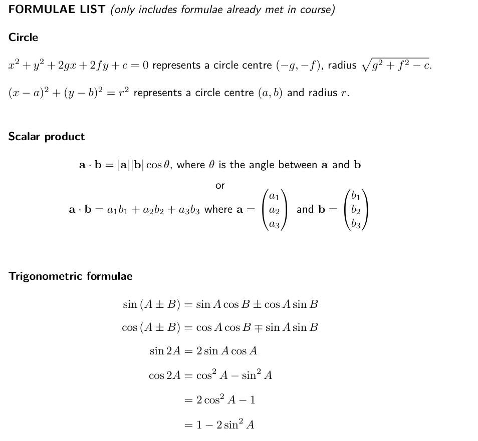

## 1 Straight Line

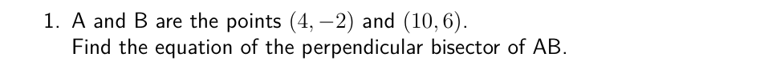

Perpendicular bisectors pass through the *midpoint* of a line segment, and run *perpendicular* to them.

*For more practice, try:* **[Zeta Higher Textbook](https://ebooks.zetapress.co.uk/yyrtww), Page 15, Exercise 1.8, Questions 1(a), 1(b) and 1(c)**

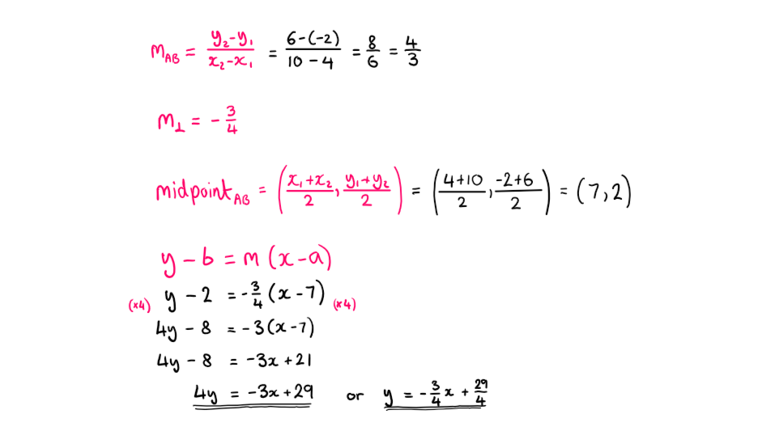

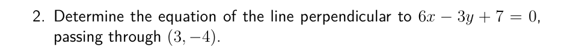

A straight line equation must be rearranged to make $y$ the subject ($y=\dots$) before its gradient can be determined.

$2y=-x-5$ or $y=-\frac{1}{2}x-\frac{5}{2}$

*For more practice, try:* **[Zeta Higher Textbook](https://ebooks.zetapress.co.uk/yyrtww), Page 13, Exercise 1.6, Questions 3, 4 and 5**

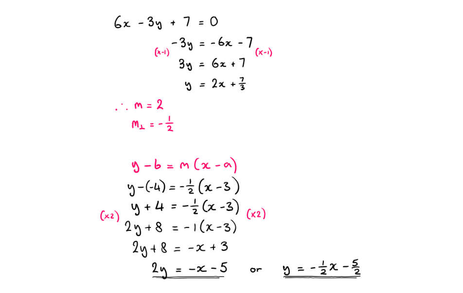

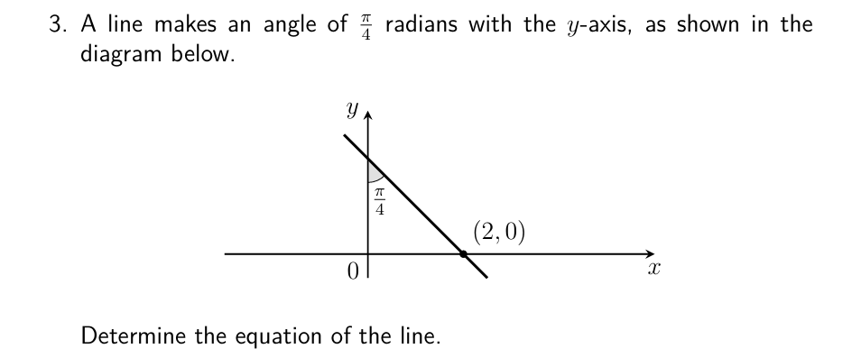

The formula $m=\tan{\theta}$ links a line's gradient to the angle it makes *with the positive direction of the* $x$*-axis*.

$y=-x+2$

*For more practice, try:* **[Zeta Higher Textbook](https://ebooks.zetapress.co.uk/yyrtww), Page 9, Exercise 1.4A, Questions 1, 2 and 3**

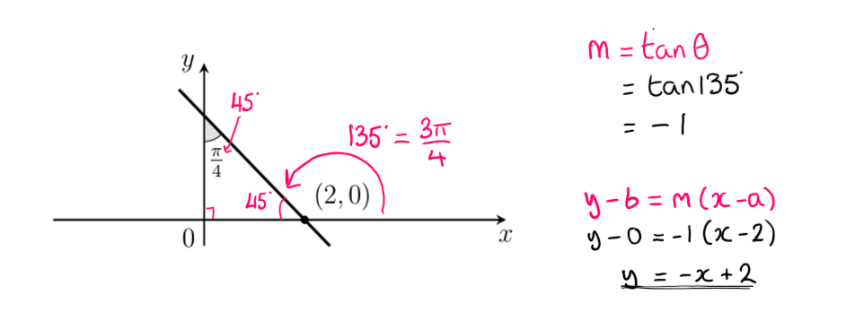

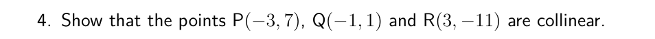

Calculate the gradients of PQ and QR first. The conclusion to a collinearity problem needs to be learned *carefully*.

$m_{PQ}=m_{QR}=-3$, valid statement *(see solution)*.

*For more practice, try:* **[Zeta Higher Textbook](https://ebooks.zetapress.co.uk/yyrtww), Page 12, Exercise 1.5, Questions 1(a), 1(b) and 1(c)**

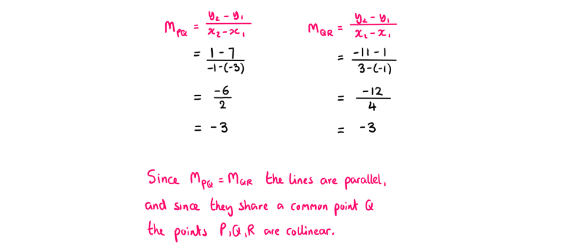

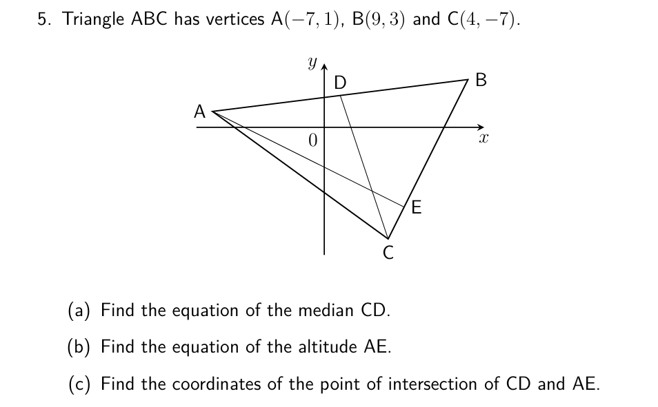

1. *Medians* meet opposite sides at the *midpoint*.
2. *Altitudes* meet opposite sides at an angle of *90 degrees*.
3. You can use $y=y$ as a first step to finding points of intersection.
1. $y=-3x+5$
2. $2y=-x-5$ or $y=-\frac{1}{2}x-\frac{5}{2}$
3. $(3,-4)$

*For more practice, try:* **[Zeta Higher Textbook](https://ebooks.zetapress.co.uk/yyrtww), Page 21, Exercise 1.11B, Questions 1, 2 and 3**

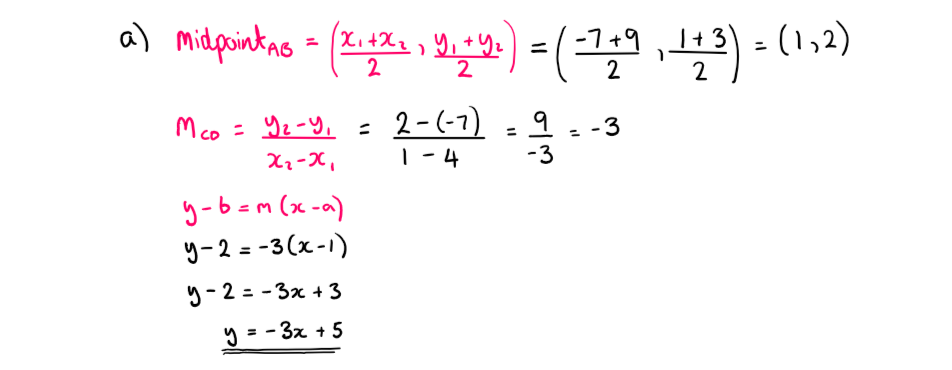

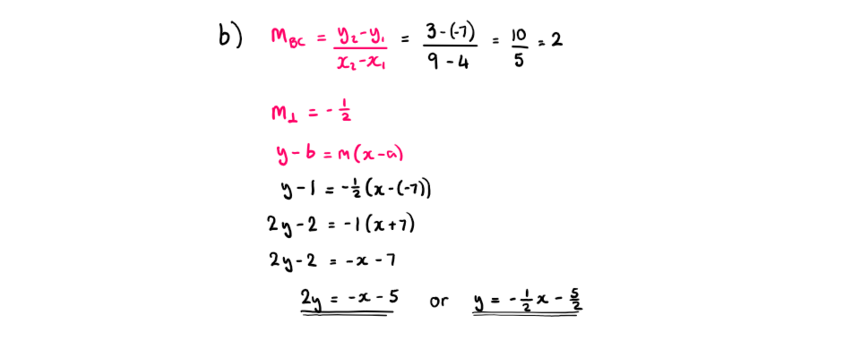

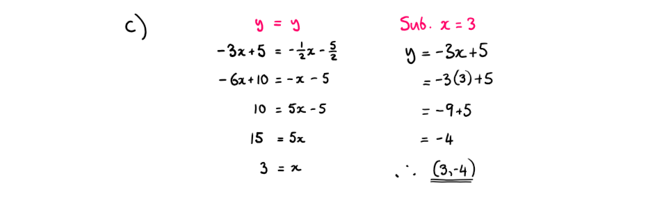

## 2 Recurrence Relations

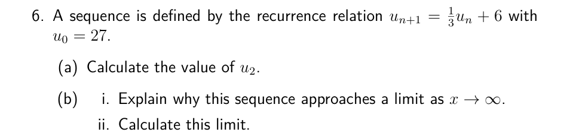

*For more practice, try:* **[Zeta Higher Textbook](https://ebooks.zetapress.co.uk/yyrtww), Page 90, Exercise 6.1, Questions 1(a), 1(b) and 1(c)**

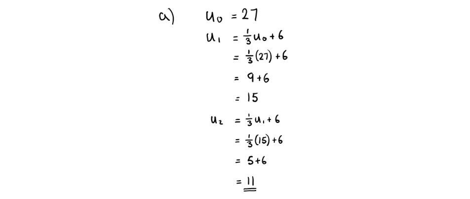

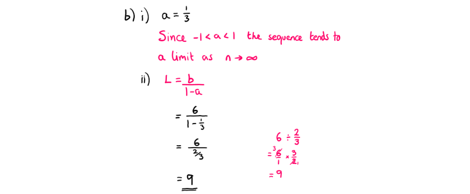

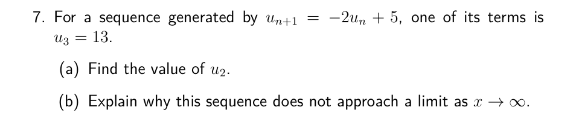

*For more practice, try:* **[Zeta Higher Textbook](https://ebooks.zetapress.co.uk/yyrtww), Page 93, Exercise 6.3, Questions 1(f), 1(i) and 1(l)**

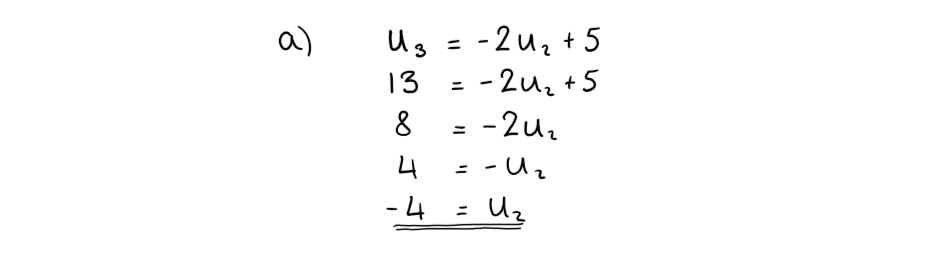

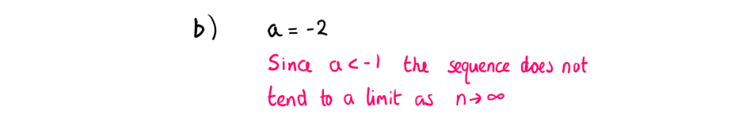

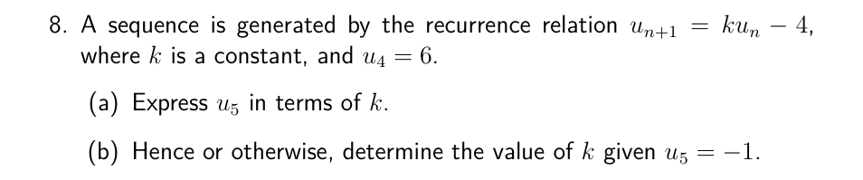

1. Substitute the value of $u_4$ into the recurrence relation.
2. Use your expression from part (a), and the new information that $u_5=-1$.
1. $6k-4$
2. $k=\frac{1}{2}$

*For more practice, try:* **[Zeta Higher Textbook](https://ebooks.zetapress.co.uk/yyrtww), Page 99, Exercise 6.6B, Questions 9, 10 and 11**

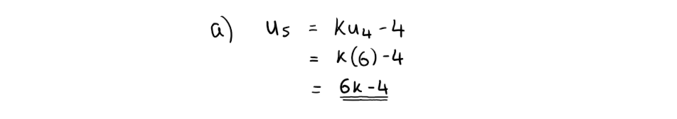

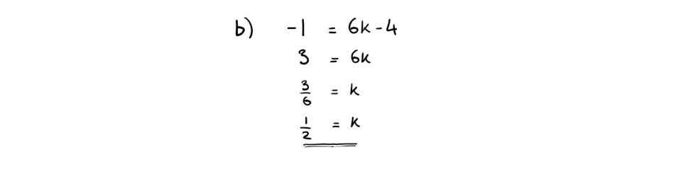

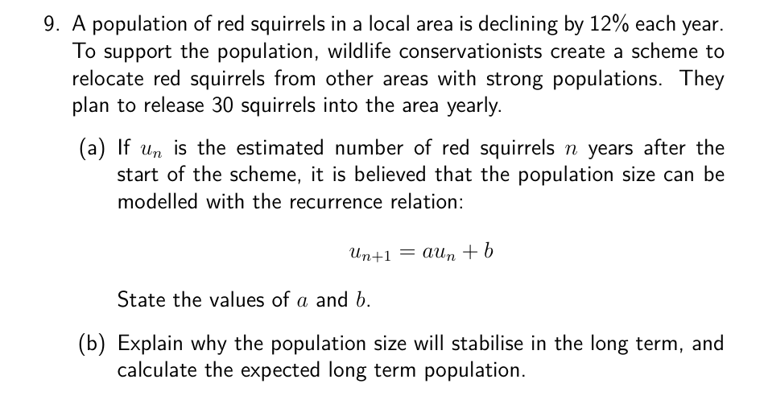

1. What *"12% is subtracted (from the original 100%)* as a decimal?
2. Since dividing by $0.12$ is tricky, multiply both parts of the fraction by $100$ and work from there.
1. $a=0.88,b-30$
2. 250 squirrels

*For more practice, try:* **[Zeta Higher Textbook](https://ebooks.zetapress.co.uk/yyrtww), Page 96, Exercise 6.5B, Questions 1, 2 and 3**

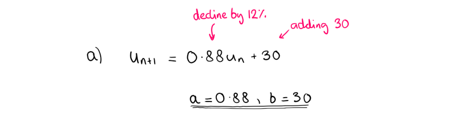

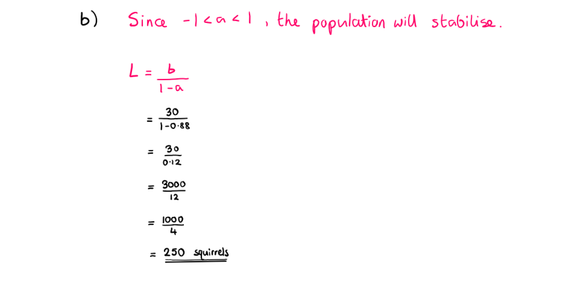

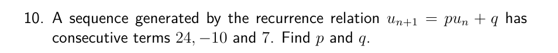

Create *two* equations: one linking the first two terms, and a second linking the second term and the third term. Solve *simultaneously*.

$p=-\frac{1}{2},q=2$

*For more practice, try:* **[Zeta Higher Textbook](https://ebooks.zetapress.co.uk/yyrtww), Page 91, Exercise 6.2, Questions 1(a), 1(b) and 1(c)**

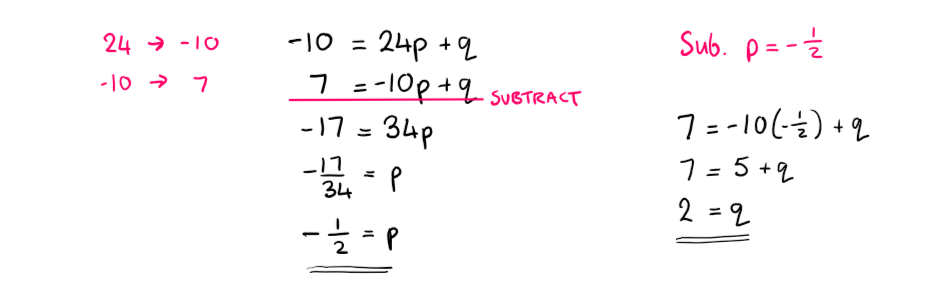